# Practical Homework 1 Decision Trees

Erdenetuya Namsrai

2025-04-06

## 1. Youth dataset

```r
url <- "https://raw.githubusercontent.com/mendible/5322/main/Homework%201/youth_data.Rdata"
download.file(url, destfile = "youth_data.Rdata", mode = "wb")

loaded_dataset <- load("youth_data.Rdata")
youth_data_df <- get(loaded_dataset[1])

cleaned_youth_data <- na.omit(youth_data_df)
youth <- cleaned_youth_data
#youth
```

## 2.1 Binary classification (e.g. has or has not used cigarettes) –>Tree with MRJFLAG –> marijuana ever used (0 = never, 1 = ever)

```r
library(tree)
library(tidyverse)

youth_binary <- cleaned_youth_data[, c(demographic_cols, youth_experience_cols, "MRJFLAG")]
youth_binary$MRJFLAG <- as.factor(youth_binary$MRJFLAG)

set.seed(123)

training_set <- sample(1:nrow(youth_binary), 0.7 * nrow(youth_binary))
training_data <- youth_binary[training_set, ]
testing_data <- youth_binary[-training_set, ]

tree_youth <- tree(MRJFLAG ~ ., data = training_data)
summary(tree_youth)
```

```
##
## Classification tree:
## tree(formula = MRJFLAG ~ ., data = training_data)
## Variables actually used in tree construction:
## [1] "FRDMJMON" "STNDSMJ"  "PRMJEVR2"
## Number of terminal nodes:  5
## Residual mean deviance:  0.6121 = 3531 / 5769
## Misclassification error rate: 0.1299 = 750 / 5774
```

```r
tree_youth
```

```
## node), split, n, deviance, yval, (yprob)
##       * denotes terminal node
##
##  1) root 5774 5084.0 0 ( 0.83963 0.16037 )
##    2) FRDMJMON: 1 4479 2212.0 0 ( 0.93257 0.06743 )
##      4) STNDSMJ: 1 905  911.2 0 ( 0.79779 0.20221 ) *
##      5) STNDSMJ: 2 3574 1044.0 0 ( 0.96670 0.03330 )
##       10) PRMJEVR2: 1 3271  707.1 0 ( 0.97738 0.02262 ) *
##       11) PRMJEVR2: 2 303  254.6 0 ( 0.85149 0.14851 ) *
##    3) FRDMJMON: 2 1295 1794.0 0 ( 0.51815 0.48185 )
##      6) STNDSMJ: 1 758 1010.0 1 ( 0.38391 0.61609 ) *
##      7) STNDSMJ: 2 537  649.0 0 ( 0.70764 0.29236 ) *
```

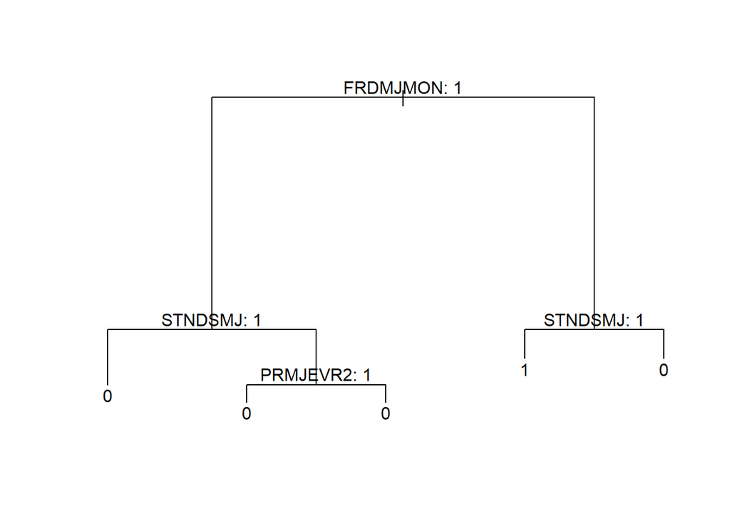

```r
plot(tree_youth)
text(tree_youth, pretty = 0)
```

```r
testing_data <- as.data.frame(testing_data)
test_pred <- predict(tree_youth, testing_data, type = "class")

confusion_matrix_dt <- table(Predicted = test_pred, Actual = testing_data$MRJFLAG)
confusion_matrix_dt
```

```
##          Actual
## Predicted    0    1
##         0 1941  215
##         1  121  198
```

```r
accuracy_dt <- mean(test_pred == testing_data$MRJFLAG)
#(198+1941)/(198+1941+121+215)
test_error_rate_dt <- 1 - accuracy_dt
#(121+215)/2475

cat('Accuracy:', mean(test_pred == testing_data$MRJFLAG), "\n")
```

```
## Accuracy: 0.8642424
```

```r
cat('Test Error Rate:', round(test_error_rate_dt, 4), "\n")
```

```
## Test Error Rate: 0.1358
```

```r
set.seed(7)

cv.youth <- cv.tree(tree_youth, FUN = prune.misclass)
names(cv.youth)
```

```
## [1] "size"   "dev"    "k"      "method"
```

```r
cv.youth
```

```
## $size
## [1] 5 3 1
##
## $dev
## [1] 764 764 926
##
## $k
## [1] -Inf    0   88
##
## $method
## [1] "misclass"
##
## attr(,"class")
## [1] "prune"         "tree.sequence"
```

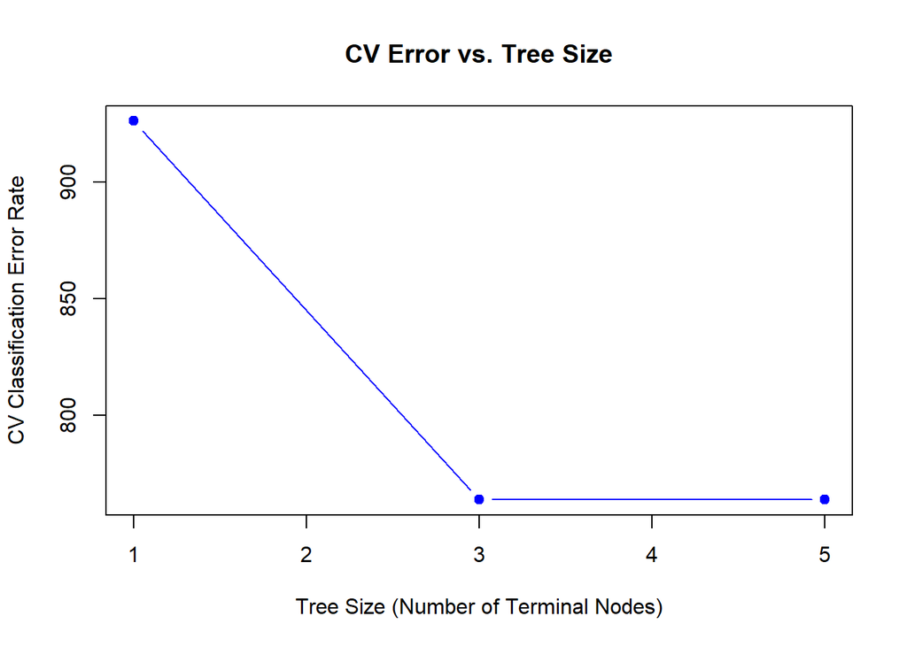

```r
plot(cv.youth$size, cv.youth$dev, type = "b",
     xlab = "Tree Size (Number of Terminal Nodes)",
     ylab = "CV Classification Error Rate",
     main = "CV Error vs. Tree Size",
     pch = 19, col = "blue")
```

```r
optimal_size_CV <- cv.youth$size[which.min(cv.youth$dev)]
optimal_size_CV
```

```
## [1] 5
```

```r
pruned_tree <- prune.misclass(tree_youth, best = 5)
pruned_tree
```

```
## node), split, n, deviance, yval, (yprob)
##       * denotes terminal node
##
##  1) root 5774 5084.0 0 ( 0.83963 0.16037 )
##    2) FRDMJMON: 1 4479 2212.0 0 ( 0.93257 0.06743 )
##      4) STNDSMJ: 1 905  911.2 0 ( 0.79779 0.20221 ) *
##      5) STNDSMJ: 2 3574 1044.0 0 ( 0.96670 0.03330 )
##       10) PRMJEVR2: 1 3271  707.1 0 ( 0.97738 0.02262 ) *
##       11) PRMJEVR2: 2 303  254.6 0 ( 0.85149 0.14851 ) *
##    3) FRDMJMON: 2 1295 1794.0 0 ( 0.51815 0.48185 )
##      6) STNDSMJ: 1 758 1010.0 1 ( 0.38391 0.61609 ) *
##      7) STNDSMJ: 2 537  649.0 0 ( 0.70764 0.29236 ) *
```

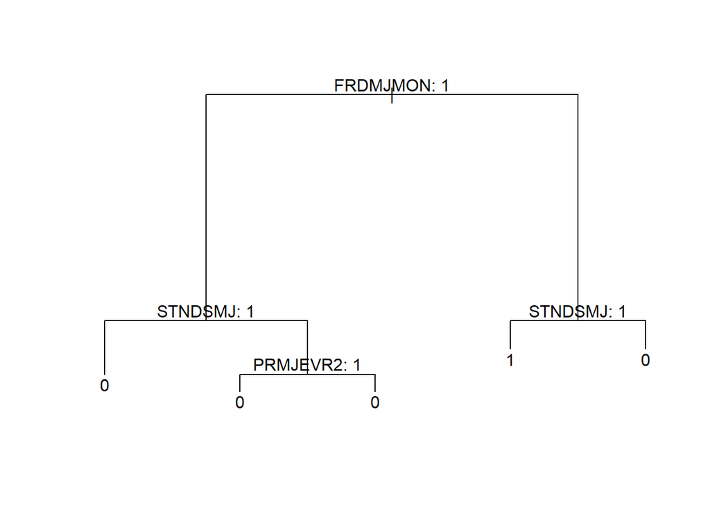

```r
plot(pruned_tree, main = "Pruned tree")
text(pruned_tree, pretty = 0)
```

```r
testing_data <- as.data.frame(testing_data)
prune_pred_youth <- predict(pruned_tree, testing_data, type = "class")

confusion_matrix_pru <- table(Predicted = prune_pred_youth, Actual = testing_data$MRJFLAG)
confusion_matrix_pru
```

```
##          Actual
## Predicted    0    1
##         0 1941  215
##         1  121  198
```

```r
accuracy_pru <- mean(prune_pred_youth == testing_data$MRJFLAG)
#(198+1941)/(198+1941+121+215)
test_error_rate_pru <- 1 - accuracy_pru
#(121+215)/2475

cat('Accuracy:', mean(prune_pred_youth == testing_data$MRJFLAG), "\n")
```

```
## Accuracy: 0.8642424
```

```r
cat('Test Error Rate:', round(test_error_rate_pru, 4), "\n")
```

```
## Test Error Rate: 0.1358
```

```r
library(randomForest)

training_data_clean <- na.omit(training_data)
bag_youth = randomForest(MRJFLAG ~ ., data = training_data_clean, mtry = floor(sqrt(ncol(training_data_clean))), importance = TRUE)
bag_youth
```

```
##
## Call:
##  randomForest(formula = MRJFLAG ~ ., data = training_data_clean,      mtry = floor(sqrt(ncol(training_data_clean))), importance = TRUE)
##                Type of random forest: classification
##                      Number of trees: 500
## No. of variables tried at each split: 7
##
##         OOB estimate of  error rate: 11.86%
## Confusion matrix:
##      0   1 class.error
## 0 4680 168  0.03465347
## 1  517 409  0.55831533
```

```r
pred_bag_youth = predict(bag_youth, newdata = testing_data, type = 'class')

confusion_matrix_bag <- table(Predicted = pred_bag_youth, Actual = testing_data$MRJFLAG)
confusion_matrix_bag
```

```
##          Actual
## Predicted    0    1
##         0 1988  231
##         1   74  182
```

```r
accuracy_bag <- mean(pred_bag_youth == testing_data$MRJFLAG)
#(180+1988)/(180+1988+74+233)
test_error_rate_bag <- 1 - accuracy_bag
#(74+233)/2475

cat('Accuracy:', mean(pred_bag_youth == testing_data$MRJFLAG), "\n")
```

```
## Accuracy: 0.8767677
```

```r
cat('Test Error Rate:', round(test_error_rate_bag, 4), "\n")
```

```
## Test Error Rate: 0.1232
```

```r
top_10_bag_MRJFLAG = head(importance(bag_youth),10)
top_10_bag_MRJFLAG
```

```
##                     0         1 MeanDecreaseAccuracy MeanDecreaseGini
## IRSEX      -1.8737844  2.782412            0.1224023         19.57523
## NEWRACE2    7.2358409 -1.921402            5.1098328         57.06084
## HEALTH2    -0.6499873  8.251551            4.8961615         45.09863
## EDUSCHLGO   7.9006482  1.690225            8.2089011         14.12366
## EDUSCHGRD2  6.1800632 17.875633           16.0387093         68.15987
## EDUSKPCOM   4.3462588  1.978839            4.7195136         45.21221
## IMOTHER    -0.3355724  1.875191            0.7093558         12.64067
## IFATHER     4.5938223  3.105877            5.5076248         20.89775
## INCOME      6.7959102  1.260030            6.8911994         36.37135
## GOVTPROG    8.1346071  2.096600            8.5733163         17.03153
```

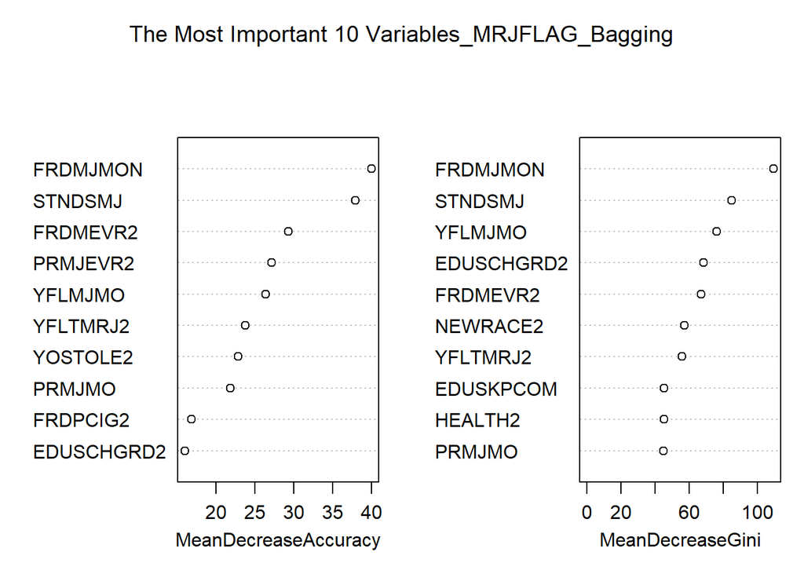

```r
varImpPlot(bag_youth, n.var = 10, sort = TRUE, main = 'The Most Important 10 Variables_MRJFLAG_Bagging')
```

## 2.3 Binary Classification –> Random Forest –> with MRJFLAG –> marijuana ever used (0 = never, 1 = ever)

```r
set.seed(1)
rf_youth = randomForest(MRJFLAG ~ ., data = training_data_clean, mtry = sqrt(ncol(training_data_clean)), importance = TRUE)
rf_youth
```

```
##
## Call:
##  randomForest(formula = MRJFLAG ~ ., data = training_data_clean,      mtry = sqrt(ncol(training_data_clean)), importance = TRUE)
##                Type of random forest: classification
##                      Number of trees: 500
## No. of variables tried at each split: 8
##
##         OOB estimate of  error rate: 12.09%
## Confusion matrix:
##      0   1 class.error
## 0 4660 188  0.03877888
## 1  510 416  0.55075594
```

```r
yhat.rf <- predict(rf_youth, newdata = testing_data, type = 'class')

confusion_matrix_rf <- table(Predicted = yhat.rf, Actual = testing_data$MRJFLAG)
confusion_matrix_rf
```

```
##          Actual
## Predicted    0    1
##         0 1985  228
##         1   77  185
```

```r
accuracy_rf <- mean(yhat.rf == testing_data$MRJFLAG, na.rm = TRUE)
test_error_rf <- 1 - accuracy_rf

cat("Accuracy:", round(accuracy_rf, 4), "\n")
```

```
## Accuracy: 0.8768
```

```r
cat("Test Error Rate:", round(test_error_rf, 4), "\n")
```

```
## Test Error Rate: 0.1232
```

```r
top_10_rf_MRJFLAG = head(importance(rf_youth),10)
top_10_rf_MRJFLAG
```

```
##                     0           1 MeanDecreaseAccuracy MeanDecreaseGini
## IRSEX      -0.1157842  3.58840417             2.081756         20.25110
## NEWRACE2    4.4962492  0.01980726             3.941679         56.91348
## HEALTH2    -1.7532805  8.92333215             4.130153         46.99917
## EDUSCHLGO   6.9505821  0.61237778             6.852772         13.36547
## EDUSCHGRD2  4.8814248 16.42028957            14.772170         70.73182
## EDUSKPCOM   4.8005257  1.03320065             4.599505         47.15655
## IMOTHER     0.0790352  2.08961310             1.271079         12.14550
## IFATHER     4.2265963  3.10415279             5.284194         20.48444
## INCOME      8.8768826  1.52806173             8.621981         37.65077
## GOVTPROG    6.9103234  6.37537191             9.724761         17.02415
```

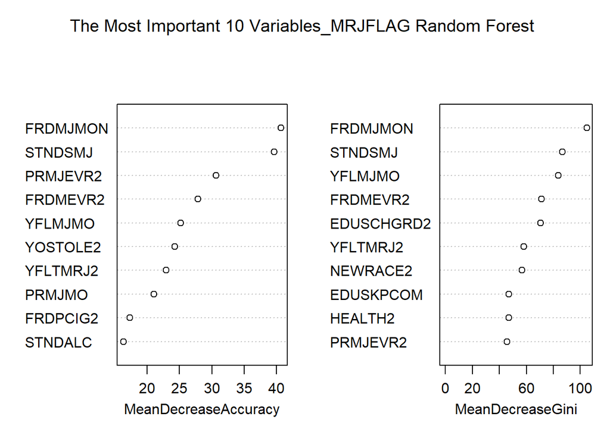

```r
varImpPlot(rf_youth, n.var = 10, sort = TRUE, main = 'The Most Important 10 Variables_MRJFLAG Random Forest ')
```

## 3.1 Binary classification (e.g. has or has not used cigarettes) Tree with TOBFLAG –> any tobacco ever used (0 = never, 1 = ever)

```r
youth_binary <- cleaned_youth_data[, c(demographic_cols, youth_experience_cols, "TOBFLAG")]
youth_binary$TOBFLAG <- as.factor(youth_binary$TOBFLAG)

set.seed(123)

training_set <- sample(1:nrow(youth_binary), 0.7 * nrow(youth_binary))
training_data <- youth_binary[training_set, ]
testing_data <- youth_binary[-training_set, ]

tree_youth2 <- tree(TOBFLAG ~ ., data = training_data)
summary(tree_youth2)
```

```
##
## Classification tree:
## tree(formula = TOBFLAG ~ ., data = training_data)
## Variables actually used in tree construction:
## [1] "FRDMJMON" "STNDSMJ"  "YOSELL2"
## Number of terminal nodes:  4
## Residual mean deviance:  0.547 = 3156 / 5770
## Misclassification error rate: 0.09318 = 538 / 5774
```

```r
tree_youth2
```

```
## node), split, n, deviance, yval, (yprob)
##       * denotes terminal node
##
## 1) root 5774 3677.00 0 ( 0.90301 0.09699 )
##   2) FRDMJMON: 1 4479 1831.00 0 ( 0.94798 0.05202 )
##     4) STNDSMJ: 1 905  665.70 0 ( 0.87956 0.12044 ) *
##     5) STNDSMJ: 2 3574 1077.00 0 ( 0.96530 0.03470 ) *
##   3) FRDMJMON: 2 1295 1464.00 0 ( 0.74749 0.25251 )
##     6) YOSELL2: 1 52   62.48 1 ( 0.28846 0.71154 ) *
##     7) YOSELL2: 2 1243 1350.00 0 ( 0.76669 0.23331 ) *
```

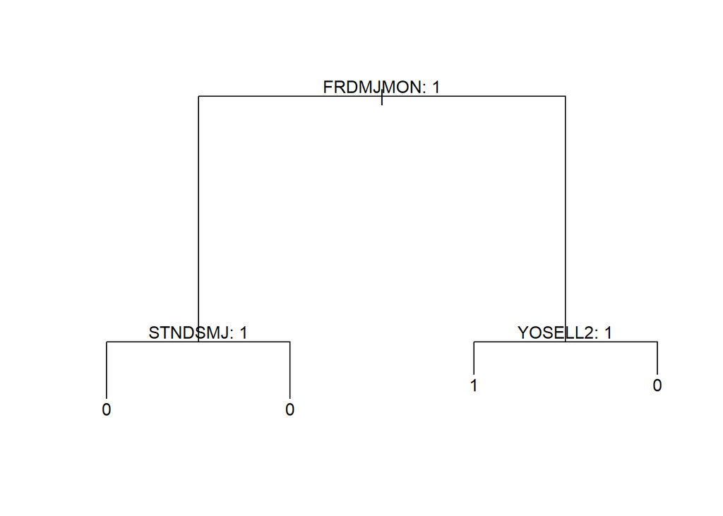

```r
plot(tree_youth2)
text(tree_youth2, pretty = 0)
```

```r
testing_data <- as.data.frame(testing_data)
test_pred <- predict(tree_youth2, testing_data, type = "class")

confusion_matrix_tobflag <- table(Predicted = test_pred, Actual = testing_data$TOBFLAG)
confusion_matrix_tobflag
```

```
##          Actual
## Predicted    0    1
##         0 2224  229
##         1    8   14
```

```r
accuracy_tobflag <- mean(test_pred == testing_data$TOBFLAG)
#(2224+14)/(2224+299+8+14)
test_error_rate_tobflag <- 1 - accuracy_tobflag
#(8+229)/2475

cat('Accuracy:', mean(test_pred == testing_data$TOBFLAG), "\n")
```

```
## Accuracy: 0.9042424
```

```r
cat('Test Error Rate:', round(test_error_rate_tobflag, 4), "\n")
```

```
## Test Error Rate: 0.0958
```

```r
set.seed(7)

cv.youth2 <- cv.tree(tree_youth2, FUN = prune.misclass)
names(cv.youth2)
```

```
## [1] "size"   "dev"    "k"      "method"
```

```r
cv.youth2
```

```
## $size
## [1] 4 3 1
##
## $dev
## [1] 547 547 560
##
## $k
## [1] -Inf    0   11
##
## $method
## [1] "misclass"
##
## attr(,"class")
## [1] "prune"         "tree.sequence"
```

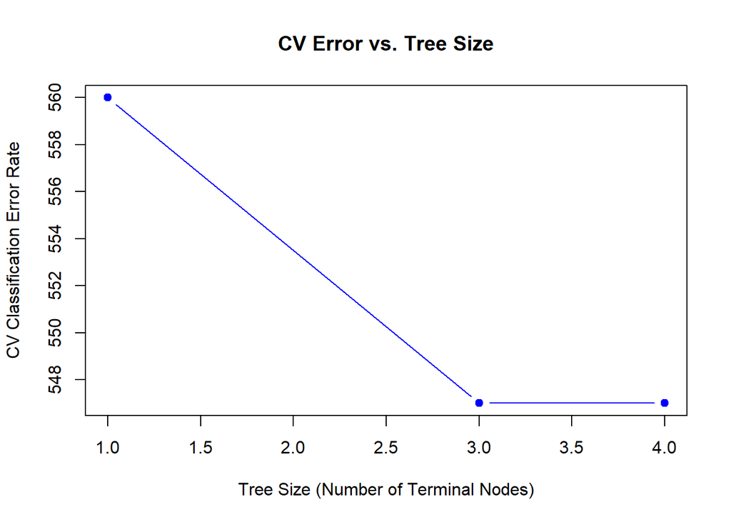

```r
plot(cv.youth2$size, cv.youth2$dev, type = "b",
     xlab = "Tree Size (Number of Terminal Nodes)",
     ylab = "CV Classification Error Rate",
     main = "CV Error vs. Tree Size",
     pch = 19, col = "blue")
```

```r
optimal_size_CV2 <- cv.youth2$size[which.min(cv.youth2$dev)]
optimal_size_CV2
```

```
## [1] 4
```

```r
pruned_tree2 <- prune.misclass(tree_youth2, best = 3)
pruned_tree2
```

```
## node), split, n, deviance, yval, (yprob)
##       * denotes terminal node
##
## 1) root 5774 3677.00 0 ( 0.90301 0.09699 )
##   2) FRDMJMON: 1 4479 1831.00 0 ( 0.94798 0.05202 ) *
##   3) FRDMJMON: 2 1295 1464.00 0 ( 0.74749 0.25251 )
##     6) YOSELL2: 1 52   62.48 1 ( 0.28846 0.71154 ) *
##     7) YOSELL2: 2 1243 1350.00 0 ( 0.76669 0.23331 ) *
```

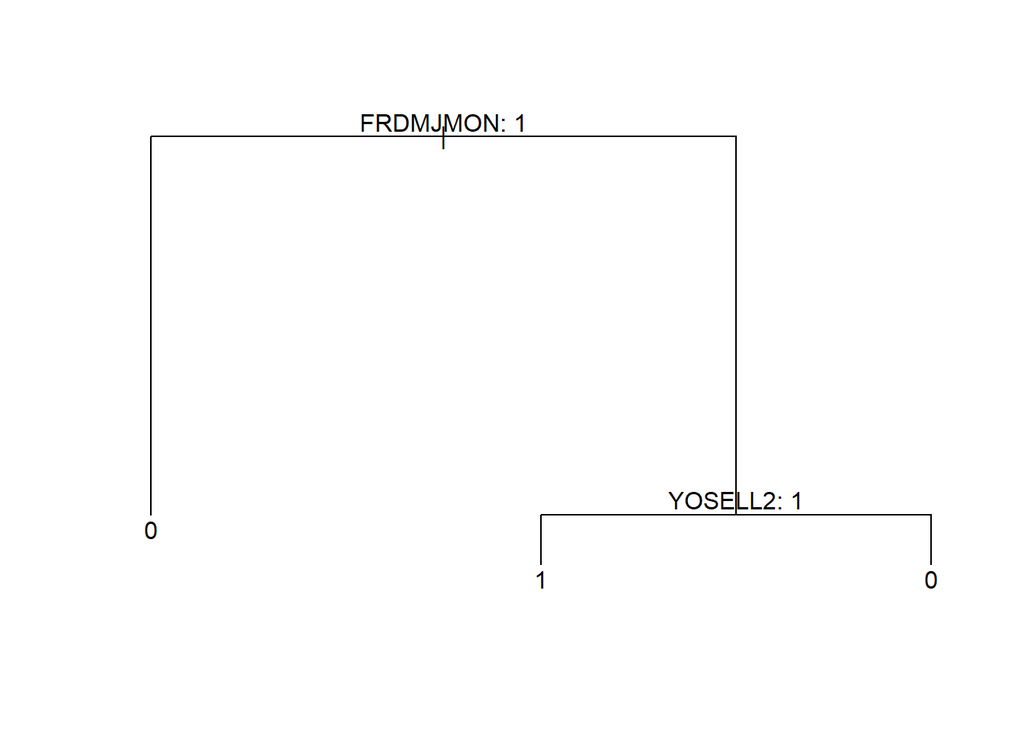

```r
plot(pruned_tree2, main = "Pruned tree")
text(pruned_tree2, pretty = 0)
```

```r
testing_data <- as.data.frame(testing_data)
prune_pred_youth2 <- predict(pruned_tree2, testing_data, type = "class")

confusion_matrix_pru2 <- table(Predicted = prune_pred_youth2, Actual = testing_data$TOBFLAG)
confusion_matrix_pru2
```

```
##          Actual
## Predicted    0    1
##         0 2224  229
##         1    8   14
```

```r
accuracy_pru2 <- mean(prune_pred_youth2 == testing_data$TOBFLAG)
#(2002+89)/(2002+89+230+154)
test_error_rate_pru2 <- 1 - accuracy_pru2
#(230+154)/2475

cat('Accuracy:', mean(prune_pred_youth2 == testing_data$TOBFLAG), "\n")
```

```
## Accuracy: 0.9042424
```

```r
cat('Test Error Rate:', round(test_error_rate_pru2, 4), "\n")
```

```
## Test Error Rate: 0.0958
```

```r
library(randomForest)

training_data_clean <- na.omit(training_data)
bag_youth2 = randomForest(TOBFLAG ~ ., data = training_data_clean, mtry = floor(sqrt(ncol(training_data_clean))), importance = TRUE)
bag_youth2
```

```
##
## Call:
##  randomForest(formula = TOBFLAG ~ ., data = training_data_clean,      mtry = floor(sqrt(ncol(training_data_clean))), importance = TRUE)
##                Type of random forest: classification
##                      Number of trees: 500
## No. of variables tried at each split: 7
##
##         OOB estimate of  error rate: 9.39%
## Confusion matrix:
##      0  1 class.error
## 0 5187 27 0.005178366
## 1  515 45 0.919642857
```

```r
pred_bag_youth2 = predict(bag_youth2, newdata = testing_data, type = 'class')

confusion_matrix_bag2 <- table(Predicted = pred_bag_youth2, Actual = testing_data$TOBFLAG)
confusion_matrix_bag2
```

```
##          Actual
## Predicted    0    1
##         0 2224  227
##         1    8   16
```

```r
accuracy_bag2 <- mean(pred_bag_youth2 == testing_data$TOBFLAG)
#(2224+16)/(2224+16+8+227)
test_error_rate_bag2 <- 1 - accuracy_bag2
#(8+227)/2475

cat('Accuracy:', mean(pred_bag_youth2 == testing_data$TOBFLAG), "\n")
```

```
## Accuracy: 0.9050505
```

```r
cat('Test Error Rate:', round(test_error_rate_bag2, 4), "\n")
```

```
## Test Error Rate: 0.0949
```

```r
top_10_bag2_TOBFLAG = head(importance(bag_youth2),10)
top_10_bag2_TOBFLAG
```

```
##                     0          1 MeanDecreaseAccuracy MeanDecreaseGini
## IRSEX       0.5575283 -1.1552127           0.03638061         15.84773
## NEWRACE2    9.9692110  1.8222799           9.66997197         49.81190
## HEALTH2    -3.4647185  8.7210754           0.78696368         38.57313
## EDUSCHLGO   3.8651035 -0.7942530           3.47124749         11.17121
## EDUSCHGRD2  4.7203605  8.9304330           8.29280269         48.85338
## EDUSKPCOM   1.1928923  1.3925700           1.66021257         37.09268
## IMOTHER    -0.8581764  2.7383526           0.49398880         10.19009
## IFATHER     0.3966267 -2.1146757          -0.41032466         16.03109
## INCOME      8.1639593 -0.2730579           7.81041058         30.07543
## GOVTPROG    4.4013270  1.6264163           4.72209606         13.72608
```

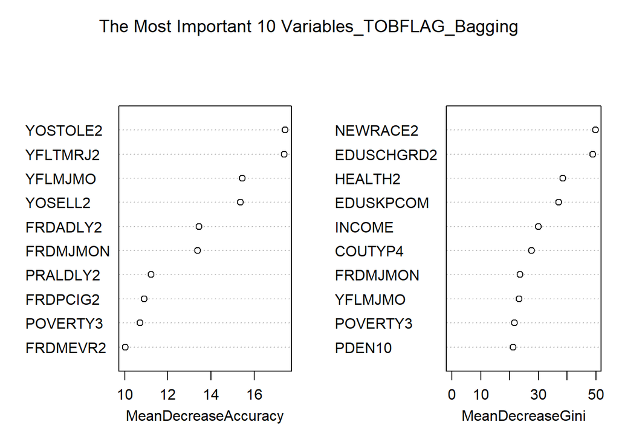

```r
varImpPlot(bag_youth2, n.var = 10, sort = TRUE, main = 'The Most Important 10 Variables_TOBFLAG_Bagging')
```

## 3.3 Binary Classification –> Random Forest –> with TOBFLAG –> any tobacco ever used (0 = never, 1 = ever)

```r
set.seed(1)
rf_youth2 = randomForest(TOBFLAG ~ ., data = training_data_clean, mtry = sqrt(ncol(training_data_clean)), importance = TRUE)
rf_youth2
```

```
##
## Call:
##  randomForest(formula = TOBFLAG ~ ., data = training_data_clean,      mtry = sqrt(ncol(training_data_clean)), importance = TRUE)
##                Type of random forest: classification
##                      Number of trees: 500
## No. of variables tried at each split: 8
##
##         OOB estimate of  error rate: 9.35%
## Confusion matrix:
##      0  1 class.error
## 0 5188 26 0.004986575
## 1  514 46 0.917857143
```

```r
yhat.rf <- predict(rf_youth2, newdata = testing_data, type = 'class')

confusion_matrix_rf2 <- table(Predicted = yhat.rf, Actual = testing_data$TOBFLAG)
confusion_matrix_rf2
```

```
##          Actual
## Predicted    0    1
##         0 2223  227
##         1    9   16
```

```r
accuracy_rf2 <- mean(yhat.rf == testing_data$TOBFLAG, na.rm = TRUE)
test_error_rate_rf2 <- 1 - accuracy_rf2

cat("Accuracy:", round(accuracy_rf2, 4), "\n")
```

```
## Accuracy: 0.9046
```

```r
cat("Test Error Rate:", round(test_error_rate_rf2, 4), "\n")
```

```
## Test Error Rate: 0.0954
```

```r
top_10_rf2_TOBFLAG = head(importance(rf_youth2),10)
top_10_rf2_TOBFLAG
```

```
##                     0          1 MeanDecreaseAccuracy MeanDecreaseGini
## IRSEX       2.2747632 -1.9374433            1.3610702         15.16408
## NEWRACE2   10.7706212  2.0182675           10.8896446         51.52574
## HEALTH2    -1.7244397  6.8033723            1.4588220         38.09800
## EDUSCHLGO   5.1332989 -0.5556501            4.9969606         10.77661
## EDUSCHGRD2  5.3339380  7.9335198            8.3243585         50.24594
## EDUSKPCOM   2.5890580  1.6953351            3.0580595         38.63693
## IMOTHER    -0.4774065  2.7254581            0.7538056         10.25463
## IFATHER     0.9609497  0.3411408            0.9917672         16.11981
## INCOME     10.0194664 -0.9962356            9.3224914         30.70777
## GOVTPROG    4.7735617  0.9069025            4.9611468         13.36711
```

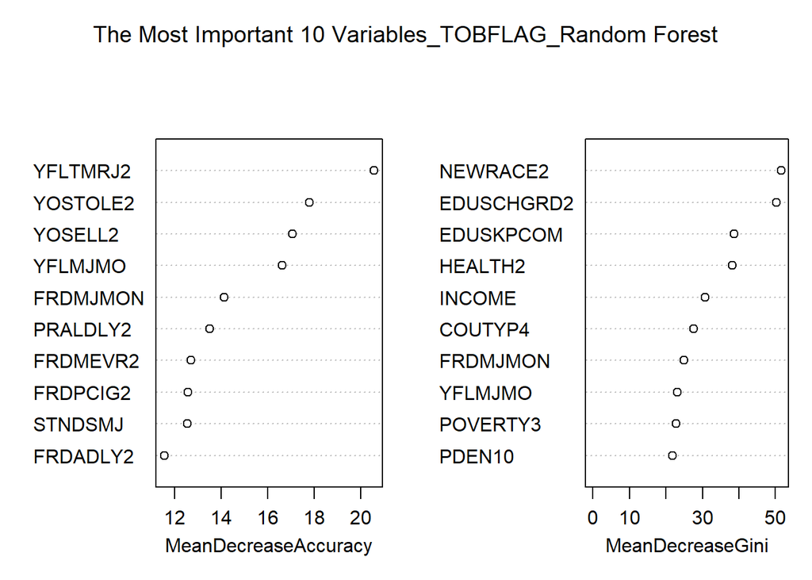

```r
varImpPlot(rf_youth2, n.var = 10, sort = TRUE, main = 'The Most Important 10 Variables_TOBFLAG_Random Forest')
```

## 4.1 Binary classification (e.g. has or has not used cigarettes) Tree with ALCFLAG –> alcohol ever used (0 = never, 1 = ever)

```r
youth_binary3 <- cleaned_youth_data[, c(demographic_cols, youth_experience_cols, "ALCFLAG")]
youth_binary3$ALCFLAG <- as.factor(youth_binary3$ALCFLAG)

set.seed(123)

training_set <- sample(1:nrow(youth_binary3), 0.7 * nrow(youth_binary3))
training_data <- youth_binary3[training_set, ]
testing_data <- youth_binary3[-training_set, ]

tree_youth3 <- tree(ALCFLAG ~ ., data = training_data)
summary(tree_youth3)
```

```
##
## Classification tree:
## tree(formula = ALCFLAG ~ ., data = training_data)
## Variables actually used in tree construction:
## [1] "STNDALC"    "YFLMJMO"    "YFLTMRJ2"   "EDUSCHGRD2"
## Number of terminal nodes:  5
## Residual mean deviance:  0.9141 = 5273 / 5769
## Misclassification error rate: 0.2037 = 1176 / 5774
```

```r
tree_youth3
```

```
## node), split, n, deviance, yval, (yprob)
##       * denotes terminal node
##
##  1) root 5774 6464.0 0 ( 0.75234 0.24766 )
##    2) STNDALC: 1 1681 2330.0 0 ( 0.50922 0.49078 )
##      4) YFLMJMO: 1 1017 1329.0 0 ( 0.64012 0.35988 ) *
##      5) YFLMJMO: 2 664  820.8 1 ( 0.30873 0.69127 ) *
##    3) STNDALC: 2 4093 3429.0 0 ( 0.85219 0.14781 )
##      6) YFLTMRJ2: 1 3409 2299.0 0 ( 0.89440 0.10560 )
##       12) EDUSCHGRD2: 1,2,3,4,98 1446  629.9 0 ( 0.94329 0.05671 ) *
##       13) EDUSCHGRD2: 5,6,7,8,9,10,99 1963 1601.0 0 ( 0.85838 0.14162 ) *
##      7) YFLTMRJ2: 2 684  892.4 0 ( 0.64181 0.35819 ) *
```

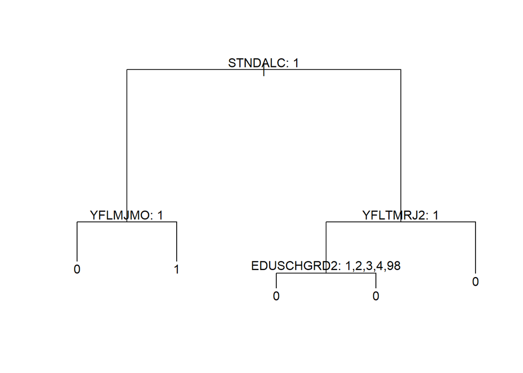

```r
plot(tree_youth3)
text(tree_youth3, pretty = 0)
```

```r
testing_data <- as.data.frame(testing_data)
test_pred <- predict(tree_youth3, testing_data, type = "class")

confusion_matrix_alcflag <- table(Predicted = test_pred, Actual = testing_data$ALCFLAG)
confusion_matrix_alcflag
```

```
##          Actual
## Predicted    0    1
##         0 1768  440
##         1   87  180
```

```r
accuracy_alcflag <- mean(test_pred == testing_data$ALCFLAG)
#(1768+180)/(1768+180+87+440)
test_error_rate_alcflag <- 1 - accuracy_alcflag
#(87+440)/2475

cat('Accuracy:', mean(test_pred == testing_data$ALCFLAG), "\n")
```

```
## Accuracy: 0.7870707
```

```r
cat('Test Error Rate:', round(test_error_rate_alcflag, 4), "\n")
```

```
## Test Error Rate: 0.2129
```

```r
set.seed(7)

cv.youth3 <- cv.tree(tree_youth3, FUN = prune.misclass)
names(cv.youth3)
```

```
## [1] "size"   "dev"    "k"      "method"
```

```r
cv.youth3
```

```
## $size
## [1] 5 3 1
##
## $dev
## [1] 1176 1176 1430
##
## $k
## [1] -Inf    0  127
##
## $method
## [1] "misclass"
##
## attr(,"class")
## [1] "prune"         "tree.sequence"
```

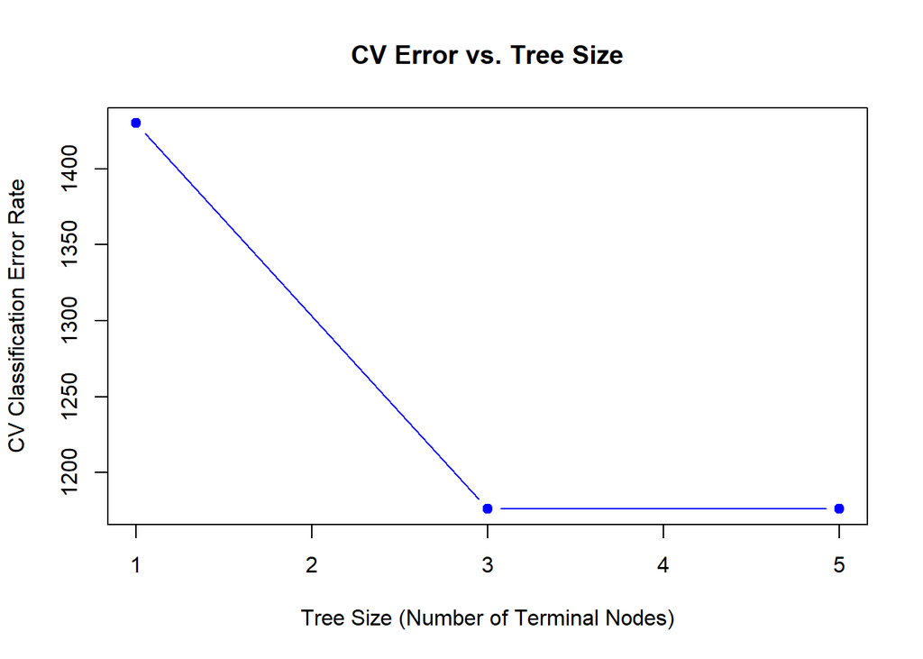

```r
plot(cv.youth3$size, cv.youth3$dev, type = "b",
     xlab = "Tree Size (Number of Terminal Nodes)",
     ylab = "CV Classification Error Rate",
     main = "CV Error vs. Tree Size",
     pch = 19, col = "blue")
```

```r
optimal_size_CV3 <- cv.youth3$size[which.min(cv.youth3$dev)]
optimal_size_CV3
```

```
## [1] 5
```

```r
pruned_tree3 <- prune.misclass(tree_youth3, best = 5)
pruned_tree3 <- prune.misclass(tree_youth3, best = 5)
pruned_tree3
```

```
## node), split, n, deviance, yval, (yprob)
##       * denotes terminal node
##
##  1) root 5774 6464.0 0 ( 0.75234 0.24766 )
##    2) STNDALC: 1 1681 2330.0 0 ( 0.50922 0.49078 )
##      4) YFLMJMO: 1 1017 1329.0 0 ( 0.64012 0.35988 ) *
##      5) YFLMJMO: 2 664  820.8 1 ( 0.30873 0.69127 ) *
##    3) STNDALC: 2 4093 3429.0 0 ( 0.85219 0.14781 )
##      6) YFLTMRJ2: 1 3409 2299.0 0 ( 0.89440 0.10560 )
##       12) EDUSCHGRD2: 1,2,3,4,98 1446  629.9 0 ( 0.94329 0.05671 ) *
##       13) EDUSCHGRD2: 5,6,7,8,9,10,99 1963 1601.0 0 ( 0.85838 0.14162 ) *
##      7) YFLTMRJ2: 2 684  892.4 0 ( 0.64181 0.35819 ) *
```

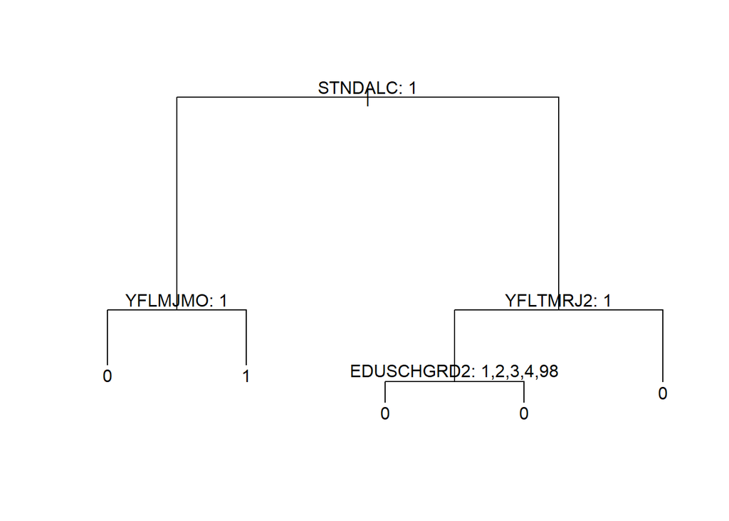

```r
plot(pruned_tree3, main = "Pruned tree")
text(pruned_tree3, pretty = 0)
```

```r
testing_data <- as.data.frame(testing_data)
prune_pred_youth3 = predict(pruned_tree3, testing_data, type = 'class')

confusion_matrix_pru3 <- table(Predicted = prune_pred_youth3, Actual = testing_data$ALCFLAG)
confusion_matrix_pru3
```

```
##          Actual
## Predicted    0    1
##         0 1768  440
##         1   87  180
```

```r
accuracy_pru3 <- mean(prune_pred_youth3 == testing_data$ALCFLAG)
#(1738+202)/(1738+202+117+418)
test_error_rate_pru3 <- 1 - accuracy_pru3
#(117+418)/2475

cat('Accuracy:', mean(prune_pred_youth3 == testing_data$ALCFLAG), "\n")
```

```
## Accuracy: 0.7870707
```

```r
cat('Test Error Rate:', round(test_error_rate_pru3, 4), "\n")
```

```
## Test Error Rate: 0.2129
```

```r
library(randomForest)

training_data_clean = na.omit(training_data)
bag_youth3 = randomForest(ALCFLAG ~ ., data = training_data_clean, mtry = floor(sqrt(ncol(training_data_clean))), importance = TRUE)
bag_youth3
```

```
##
## Call:
##  randomForest(formula = ALCFLAG ~ ., data = training_data_clean,      mtry = floor(sqrt(ncol(training_data_clean))), importance = TRUE)
##                Type of random forest: classification
##                      Number of trees: 500
## No. of variables tried at each split: 7
##
##         OOB estimate of  error rate: 19.61%
## Confusion matrix:
##      0   1 class.error
## 0 4075 269  0.06192449
## 1  863 567  0.60349650
```

```r
pred_bag_youth3 = predict(bag_youth3, newdata = testing_data, type = 'class')

confusion_matrix_bag3 <- table(Predicted = pred_bag_youth3, Actual = testing_data$ALCFLAG)
confusion_matrix_bag3
```

```
##          Actual
## Predicted    0    1
##         0 1735  379
##         1  120  241
```

```r
accuracy_bag3 <- mean(pred_bag_youth3 == testing_data$ALCFLAG)
#(2224+16)/(2224+16+8+227)
test_error_rate_bag3 <- 1 - accuracy_bag3
#(8+227)/2475

cat('Accuracy:', mean(pred_bag_youth3 == testing_data$ALCFLAG), "\n")
```

```
## Accuracy: 0.7983838
```

```r
cat('Test Error Rate:', round(test_error_rate_bag3, 4), "\n")
```

```
## Test Error Rate: 0.2016
```

```r
top_10_bag3_ALCFLAG = head(importance(bag_youth3),10)
top_10_bag3_ALCFLAG
```

```
##                     0            1 MeanDecreaseAccuracy MeanDecreaseGini
## IRSEX       0.8140106  1.752712436             1.703886         34.15393
## NEWRACE2   12.2530463  1.944899845            11.948808         96.32596
## HEALTH2     1.6482554  3.838190565             3.443447         69.87464
## EDUSCHLGO   8.9453423 -3.779807662             6.501898         17.71229
## EDUSCHGRD2 15.3954957 22.938638280            27.811631        124.40449
## EDUSKPCOM   7.2677393  1.485427503             7.322552         70.60417
## IMOTHER    -1.5786681 -1.353060887            -2.061123         19.21708
## IFATHER     8.5383233  0.311178438             7.774197         31.93798
## INCOME     11.1817173  5.011496717            13.528991         58.35479
## GOVTPROG   10.1807735 -0.001320414             9.104788         26.70772
```

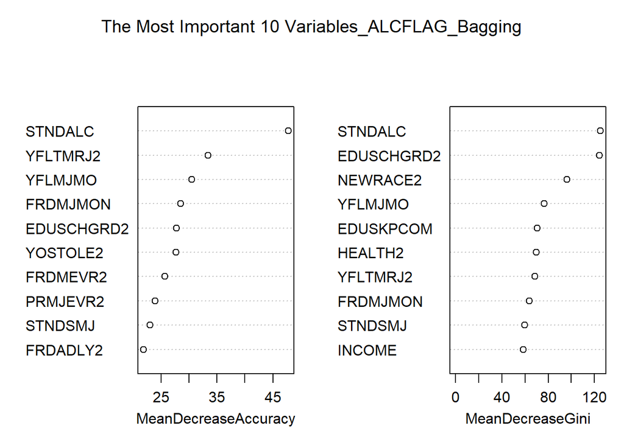

```r
varImpPlot(bag_youth3, n.var = 10, sort = TRUE, main = 'The Most Important 10 Variables_ALCFLAG_Bagging')
```

## 4.3 Binary Classification –> Random Forest –> with ALCFLAG –> alcohol ever used (0 = never, 1 = ever)

```r
set.seed(1)
rf_youth3 = randomForest(ALCFLAG ~ ., data = training_data_clean, mtry = sqrt(ncol(training_data_clean)), importance = TRUE)
rf_youth3
```

```
##
## Call:
##  randomForest(formula = ALCFLAG ~ ., data = training_data_clean,      mtry = sqrt(ncol(training_data_clean)), importance = TRUE)
##                Type of random forest: classification
##                      Number of trees: 500
## No. of variables tried at each split: 8
##
##         OOB estimate of  error rate: 19.64%
## Confusion matrix:
##      0   1 class.error
## 0 4074 270   0.0621547
## 1  864 566   0.6041958
```

```r
yhat.rf <- predict(rf_youth3, newdata = testing_data, type = 'class')

confusion_matrix_rf3 <- table(Predicted = yhat.rf, Actual = testing_data$ALCFLAG)
confusion_matrix_rf3
```

```
##          Actual
## Predicted    0    1
##         0 1737  370
##         1  118  250
```

```r
accuracy_rf3 <- mean(yhat.rf == testing_data$ALCFLAG, na.rm = TRUE)
test_error_rate_rf3 <- 1 - accuracy_rf3

cat("Accuracy:", round(accuracy_rf3, 4), "\n")
```

```
## Accuracy: 0.8028
```

```r
cat("Test Error Rate:", round(test_error_rate_rf3, 4), "\n")
```

```
## Test Error Rate: 0.1972
```

```r
top_10_rf3_ALCFLAG = head(importance(rf_youth3),10)
top_10_rf3_ALCFLAG
```

```
##                     0          1 MeanDecreaseAccuracy MeanDecreaseGini
## IRSEX       1.5446554  2.3695415             2.572437         34.00565
## NEWRACE2   12.4431278  1.4848483            12.004452         99.48005
## HEALTH2     2.1927509  3.4885197             3.845355         72.32937
## EDUSCHLGO   8.3060529 -1.9704074             6.541364         17.58747
## EDUSCHGRD2 13.9505678 24.4614246            25.466823        125.63018
## EDUSKPCOM   6.8892816  1.7687471             6.940890         72.55806
## IMOTHER     0.7204869  1.2010987             1.304357         19.80173
## IFATHER     9.4159226 -0.9525001             8.055968         31.98522
## INCOME     12.2294913  4.7666007            13.825365         59.90346
## GOVTPROG   10.8882297  1.5089353            10.887644         26.26350
```

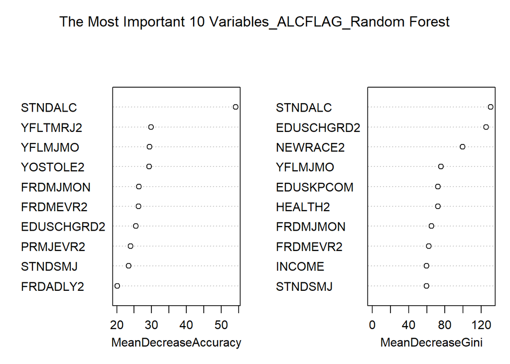

```r
varImpPlot(rf_youth3, n.var = 10, sort = TRUE, main = 'The Most Important 10 Variables_ALCFLAG_Random Forest')
```

## 5.1 Compare Binary Classification Methods —> Tree with MRJFLAG –> Marijuana ever used (0 = never, 1 = ever)

[figure not shown]

```r
library(ggplot2)

model_names <- c("Decision Tree", "Pruned Tree", "Bagging", "Random Forest")
accuracy_values <- c(accuracy_dt, accuracy_pru2, accuracy_bag2, accuracy_rf2)
error_rate_values <- c(test_error_rate_dt, test_error_rate_pru2, test_error_rate_bag2, test_error_rate_rf2)

comparison_df <- data.frame(
  Model = rep(model_names, times = 2),
  Metric = rep(c("Accuracy", "Test Error Rate"), each = length(model_names)),
  Value = c(accuracy_values, error_rate_values)
)

ggplot(comparison_df, aes(x = Model, y = Value, fill = Metric)) +
  geom_bar(stat = "identity", position = "dodge") +
  geom_text(aes(label = paste0(round(Value * 100, 1), "%")),
            position = position_dodge(width = 0.9),
            vjust = -0.3, size = 3.5) +
  labs(title = "Accuracy vs Test Error Rate with Marijuana",
       x = "Model", y = "Percentage") +
  theme_minimal() +
  ylim(0, 1)
```

## 5.2 Compare Binary Classification Methods —> Tree with TOBFLAG –> any Tobacco ever used (0 = never, 1 = ever)

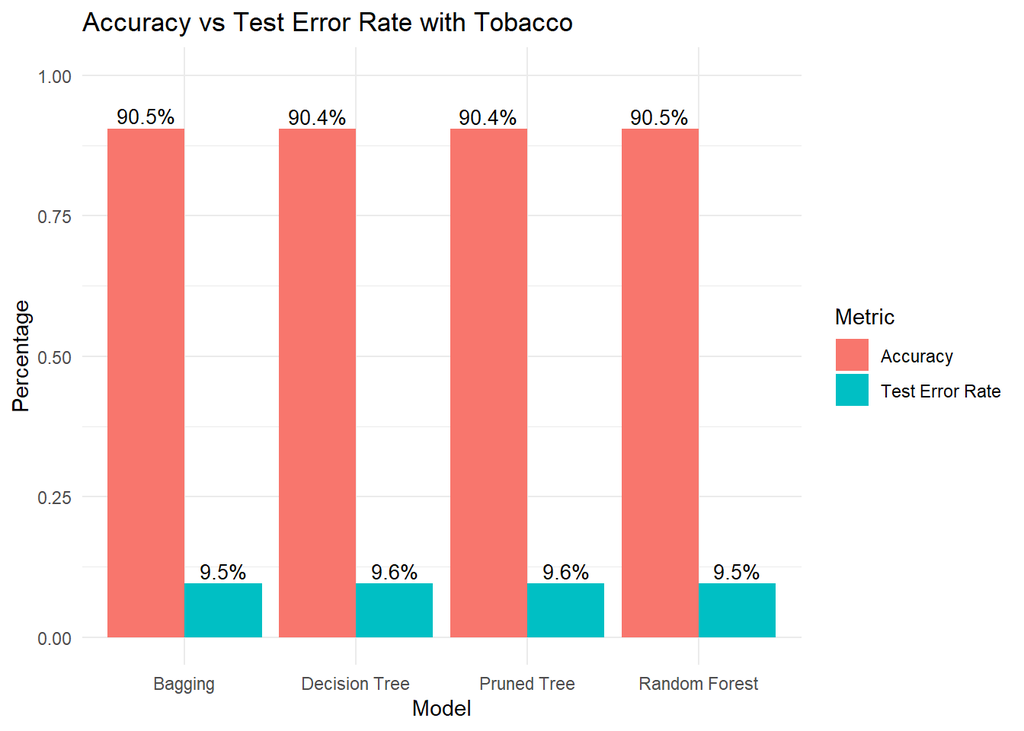

```r
library(ggplot2)

model_names <- c("Decision Tree", "Pruned Tree", "Bagging", "Random Forest")
accuracy_values <- c(accuracy_tobflag, accuracy_pru2, accuracy_bag2, accuracy_rf2)
error_rate_values <- c(test_error_rate_tobflag, test_error_rate_pru2, test_error_rate_bag2, test_error_rate_rf2)

comparison_df <- data.frame(
  Model = rep(model_names, times = 2),
  Metric = rep(c("Accuracy", "Test Error Rate"), each = length(model_names)),
  Value = c(accuracy_values, error_rate_values)
)

# Bar plot with percentage labels
ggplot(comparison_df, aes(x = Model, y = Value, fill = Metric)) +
  geom_bar(stat = "identity", position = "dodge") +
  geom_text(aes(label = paste0(round(Value * 100, 1), "%")),
            position = position_dodge(width = 0.9),
            vjust = -0.3, size = 3.5) +
  labs(title = "Accuracy vs Test Error Rate with Tobacco",
       x = "Model", y = "Percentage") +
  theme_minimal() +
  ylim(0, 1)
```

## 5.3 Compare Binary Classification Methods —> Tree with ALCFLAG –> Alcohol ever used (0 = never, 1 = ever)

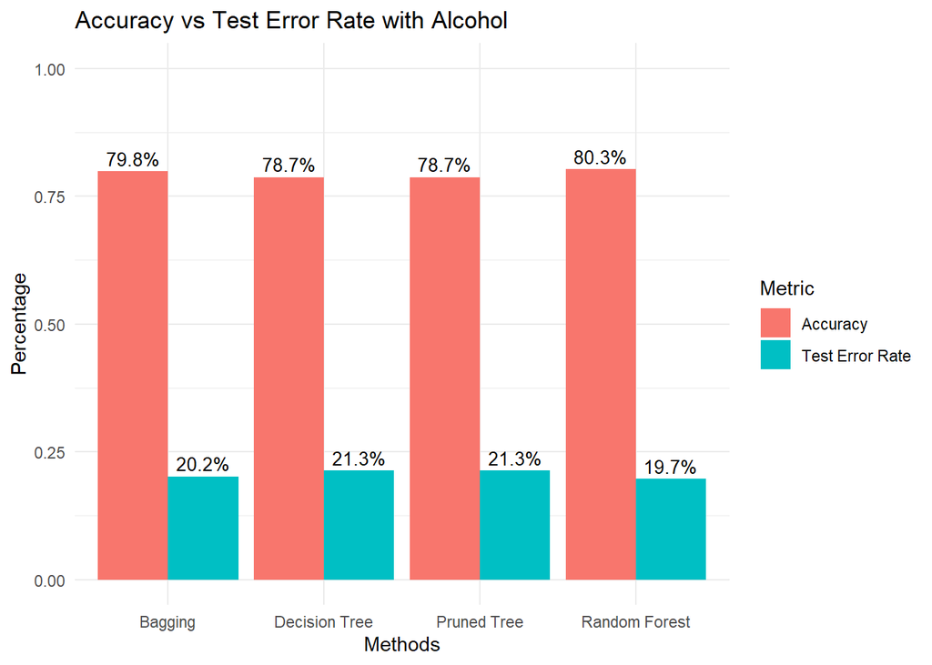

```r
library(ggplot2)

model_names <- c("Decision Tree", "Pruned Tree", "Bagging", "Random Forest")
accuracy_values <- c(accuracy_alcflag, accuracy_pru3, accuracy_bag3, accuracy_rf3)
error_rate_values <- c(test_error_rate_alcflag, test_error_rate_pru3, test_error_rate_bag3, test_error_rate_rf3)

comparison_df <- data.frame(
  Model = rep(model_names, times = 2),
  Metric = rep(c("Accuracy", "Test Error Rate"), each = length(model_names)),
  Value = c(accuracy_values, error_rate_values)
)

ggplot(comparison_df, aes(x = Model, y = Value, fill = Metric)) +
  geom_bar(stat = "identity", position = position_dodge()) +
  geom_text(aes(label = paste0(round(Value * 100, 1), "%")),
            position = position_dodge(width = 0.9),
            vjust = -0.4, size = 3.5) +
  labs(title = "Accuracy vs Test Error Rate with Alcohol",
       x = "Methods", y = "Percentage") +
  theme_minimal() +
  ylim(0, 1)
```

## 5.4 Binary Model Comparison: Accuracy vs Test Error Rate for Each Model

[figure not shown]

```r
library(ggplot2)

model_names <- c("Decision Tree", "Pruned Tree", "Bagging", "Random Forest")

accuracy_marijuana <- c(accuracy_dt, accuracy_pru2, accuracy_bag2, accuracy_rf2)
error_marijuana    <- c(test_error_rate_dt, test_error_rate_pru2, test_error_rate_bag2, test_error_rate_rf2)

accuracy_tobacco <- c(accuracy_tobflag, accuracy_pru2, accuracy_bag2, accuracy_rf2)
error_tobacco    <- c(test_error_rate_tobflag, test_error_rate_pru2, test_error_rate_bag2, test_error_rate_rf2)

accuracy_alcohol <- c(accuracy_alcflag, accuracy_pru3, accuracy_bag3, accuracy_rf3)
error_alcohol    <- c(test_error_rate_alcflag, test_error_rate_pru3, test_error_rate_bag3, test_error_rate_rf3)

substances <- c("Marijuana", "Tobacco", "Alcohol")
x_labels <- paste(rep(substances, each = length(model_names)),
                  rep(model_names, times = length(substances)),
                  sep = " - ")

comparison_df <- data.frame(
  Method = rep(x_labels, times = 2),
  Metric = rep(c("Accuracy", "Test Error Rate"), each = length(x_labels)),
  Value = c(accuracy_marijuana, accuracy_tobacco, accuracy_alcohol,
            error_marijuana, error_tobacco, error_alcohol)
)

custom_palette <- c("Accuracy" = "#0072B2", "Test Error Rate" = "#56B4E9")

# Plot
ggplot(comparison_df, aes(x = Method, y = Value, fill = Metric)) +
  geom_bar(stat = "identity", position = position_dodge()) +
  geom_text(aes(label = paste0(round(Value * 100, 1), "%")),
            position = position_dodge(width = 0.9),
            vjust = -0.25, size = 3) +
  scale_fill_manual(values = custom_palette) +
  labs(title = "Binary Model Comparison: Accuracy vs Test Error Rate for Each Model",
       x = "All Binary Models", y = "Percentage") +
  theme_minimal() +
  ylim(0, 1) +
  theme(axis.text.x = element_text(angle = 45, hjust = 1))
```

## 6. The Subset of Best 22 features from the Binary Models

```r
url <- "https://raw.githubusercontent.com/mendible/5322/main/Homework%201/youth_data.Rdata"
download.file(url, destfile = "youth_data.Rdata", mode = "wb")

loaded_dataset <- load("youth_data.Rdata")
youth_data_df <- get(loaded_dataset[1])

cleaned_youth_data <- na.omit(youth_data_df)
youth <- cleaned_youth_data

if (!"PRADLY2" %in% names(youth)) {
  youth$PRADLY2 <- NA
}

important_vars <- c(
  "YFLMJMO", "FRDMJMON", "YFLTMRJ2", "EDUSCHGRD2", "STNDSMJ",
  "FRDMEVR2", "YOSTOLE2", "NEWRACE2", "HEALTH2", "EDUSKPCOM",
  "PRMJEVR2", "STNDALC", "INCOME", "FRDPCIG2", "FRDADLY2",
  "POVERTY3", "PRMJMO", "PDEN10", "YOSELL2", "COUTYP4",
  "PRALDLY2", "PRADLY2"
)

target_vars <- c("MRJFLAG", "TOBFLAG", "ALCFLAG")

all_vars <- unique(c(important_vars, target_vars))
existing_vars <- all_vars[all_vars %in% names(youth)]

youth_fltrd <- youth[, existing_vars]
#youth_fltrd
```